# SRJPE Data Review: yuba river

October 09, 2026

This report summarizes data for **yuba river** to support stream team review ahead of model runs.

Included within the zipped data folder are full datatables for:

- adult data (table of annual estimates being used in stock recruit modeling)
- adult_model_years (summary of any years being excluded in the adult dataset)
- flow and temperature datasets (flow and temperature data pulled from gages)
- rst_model_years (summary of any years being excluded in juvenile abundance modeling)
- weekly_catch (catch data summarized by week, refer to the diagram for information about data processing)
- weekly_eff (efficiency data summarized by week)

Please confirm that the years-excluded tables below are still correct, that we are using the best source for environmental data, and flag anything that looks off in the catch, efficiency, or environmental sections. Visualizations below will highlight points that are outliers to help you QC.

## Data Summary

- we have **17** years of RST data
- we have **18** years of adult data, the adult data source that is being used in the Stock Recruit for this stream is **passage**

## Years Excluded

### Adult Data

We are excluding the following adult data years from analysis.

```
## No adult years excluded in this range for yuba river
```

### RST (Juvenile Outmigrant) Data

We are excluding the following rst data years from analysis.

RST years excluded – yuba river

| Year | Site | Reason for exclusion |
| --- | --- | --- |
| 2003 | hallwood | 60% of weeks sampled |
| 2022 | hallwood | 60% of weeks sampled |

## Catch

The following plots show percent cumulative catch, cumulative catch, and absolute catch timeserries for **yuba river**, The goal of these plots is to quickly review catch across years to see if there are any years that look inaccurate or any weeks that have unrealistic catch values.

### Percent Cumulative Catch

[interactive chart not shown]

### Absolute Cumulative Catch

[interactive chart not shown]

### Catch Timeserries

[interactive chart not shown]

## Trap Efficiency

Efficiency trial summary for yuba river

| stream | site | min_run_year | max_run_year | total_trials | total_released | total_recaptured |
| --- | --- | --- | --- | --- | --- | --- |
| yuba river | hallwood | 2023 | 2026 | 65 | 47306 | 1006 |

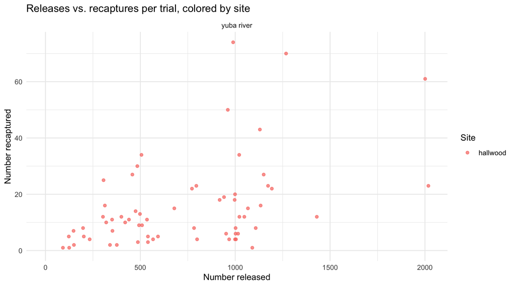

## Environmental Data

> **Gage reminder:** We are using gage **USGS-11421000** for flow data and **CDEC - YR7 (interpolated)** for temperature data. Please let us know if there are better data sources to utilize for environmental data.

### Flow

The plot below shows weekly flow over time on **yuba river**. Each line is colored by the year. Hover over a line to see additional information.

Flags negative flow (physically impossible) as well as statistical outliers per site (values beyond the median +/- 5 times the interquartile range).

Note: the jagged jump seen every year right at Jan 1 is a data-binning artifact (the “week 53” bin covers only 1-2 days instead of 7), not a real flow swing.

[interactive chart not shown]

### Temperature

The plot below shows weekly temperature over time on **yuba river**. Each line is colored by the year. Hover over a line to see additional information.

Flags values below -5C or above 35C as biologically implausible.

Note: the jagged jump seen every year right at Jan 1 is a data-binning artifact (the “week 53” bin covers only 1-2 days instead of 7), not a real temperature swing.

> **Note:** some temperature values for yuba river are interpolated (see gage reminder above).

[interactive chart not shown]